# Assignment 1 Macro

Mohamed Sabath_COHNDDS23.1F-007

2023-09-08

```r
setwd("D:/Data science NIBM/HND/Macroeconomics/Assignment 1")
```

step 1 :Data Exploration

```r
# Load the readxl package
library(readxl)

# Load the data from the Excel file
data <- read_excel("CA 1 Data set.xlsx")


# first few rows of the dataset
head(data)
```

```
## # A tibble: 6 × 6
##    Year    ST    EI    IH `GDP ($Mn)` `BI ($Mn)`
##   <dbl> <dbl> <dbl> <dbl>       <dbl>      <dbl>
## 1  1983 0.335 0.623  2.06        168.       40.7
## 2  1984 0.33  0.616  2.1         298.       78.6
## 3  1985 0.335 0.647  2.17        102.       32.1
## 4  1986 0.33  0.652  2.21        124.       38.1
## 5  1987 0.334 0.68   2.23        146.       56.1
## 6  1988 0.325 0.682  2.2         158.       56.3
```

Step 2: Data Loading and Cleaning

```r
# Checking for missing values
colSums(is.na(data))
```

```
##      Year        ST        EI        IH GDP ($Mn)  BI ($Mn)
##         0         0         0         0         0         0
```

it has no null values.

Step 3 : Descriptive Statistics and Visualization.

```r
# Getting basic information about the dataset
str(data)
```

```
## tibble [41 × 6] (S3: tbl_df/tbl/data.frame)
##  $ Year     : num [1:41] 1983 1984 1985 1986 1987 ...
##  $ ST       : num [1:41] 0.335 0.33 0.335 0.33 0.334 0.325 0.344 0.358 0.37 0.342 ...
##  $ EI       : num [1:41] 0.623 0.616 0.647 0.652 0.68 0.682 0.669 0.7 0.679 0.729 ...
##  $ IH       : num [1:41] 2.06 2.1 2.17 2.21 2.23 2.2 2.26 2.34 2.21 2.22 ...
##  $ GDP ($Mn): num [1:41] 168 298 102 124 146 ...
##  $ BI ($Mn) : num [1:41] 40.7 78.7 32.1 38.1 56.1 ...
```

```r
# Getting summary statistics for numerical columns
summary(data)
```

```
##       Year            ST               EI               IH
##  Min.   :1983   Min.   :0.3120   Min.   :0.6160   Min.   :2.060
##  1st Qu.:1993   1st Qu.:0.3300   1st Qu.:0.7290   1st Qu.:2.470
##  Median :2003   Median :0.3370   Median :0.8740   Median :2.630
##  Mean   :2003   Mean   :0.3413   Mean   :0.9053   Mean   :2.631
##  3rd Qu.:2013   3rd Qu.:0.3540   3rd Qu.:1.0340   3rd Qu.:2.810
##  Max.   :2023   Max.   :0.3970   Max.   :1.2960   Max.   :3.330
##    GDP ($Mn)        BI ($Mn)
##  Min.   :102.3   Min.   :32.12
##  1st Qu.:148.9   1st Qu.:40.89
##  Median :192.3   Median :56.26
##  Mean   :206.7   Mean   :54.33
##  3rd Qu.:232.0   3rd Qu.:64.08
##  Max.   :498.2   Max.   :95.44
```

```r
# Getting the list of column names
colnames(data)
```

```
## [1] "Year"      "ST"        "EI"        "IH"        "GDP ($Mn)" "BI ($Mn)"
```

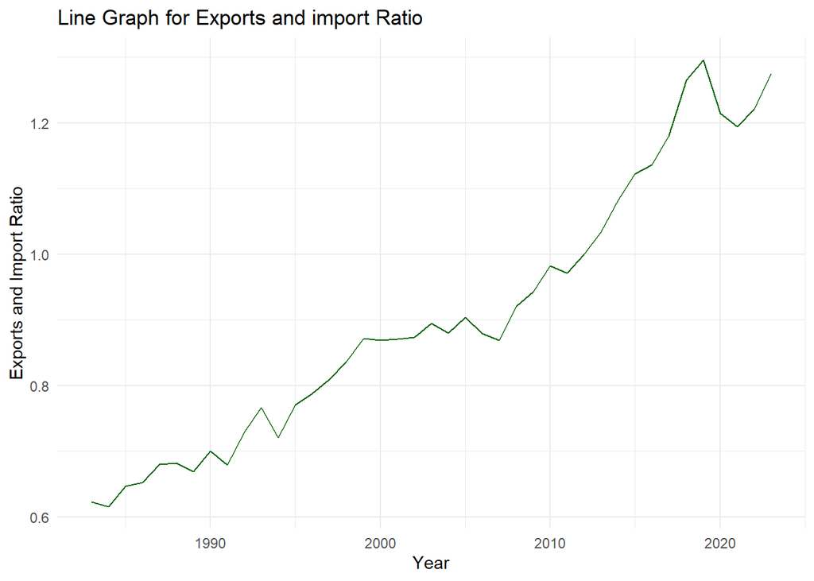

```r
library(ggplot2)
ggplot(data, aes(x = Year, y = EI,)) +
  geom_line(color = "darkgreen") +
  scale_color_brewer(palette = "Set1") +
  labs(title = "Line Graph for Exports and import Ratio",
       x = "Year",
       y = "Exports and Import Ratio") +
  theme_minimal()
```

#Here it looks like by the year 2012 it has reached the ratio of 1.0 which means imports = exports.

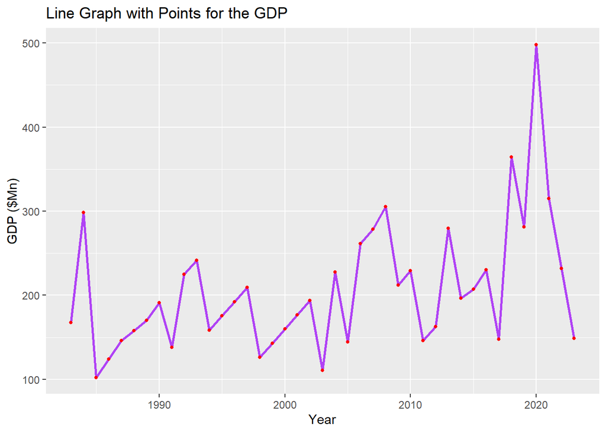

```r
# Customized line graph with points
ggplot(data, aes(x = Year, y = `GDP ($Mn)`)) +
  geom_line(color = "#b042f5",size = 1) +
  geom_point(shape = 16, size = 1, color = "red") +
  labs(x = "Year", y = "GDP ($Mn)", title = "Line Graph with Points for the GDP")
```

```r
  scale_x_continuous(breaks = seq(min(data$Year), max(data$Year), by = 2))
```

```
## <ScaleContinuousPosition>
##  Range:
##  Limits:    0 --    1
```

Seems like by 1984 the gdp was 300mn. But after that we can see a continous decreament on the gdp until 1885.

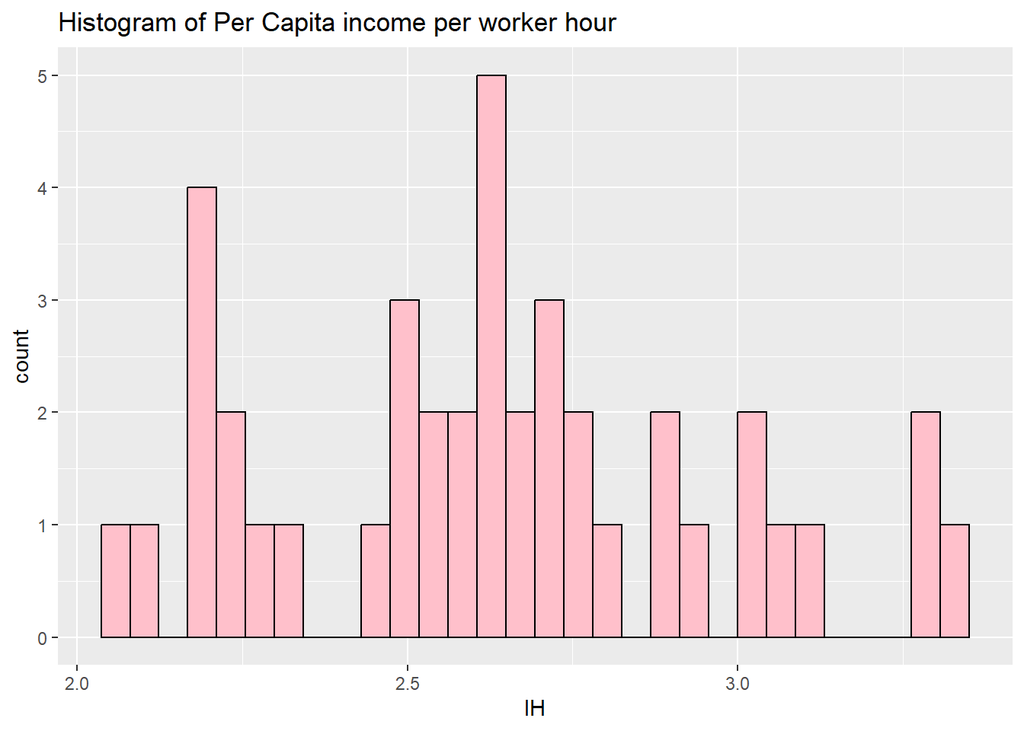

```r
ggplot(data, aes(x = IH,)) +
  geom_histogram(fill = "pink", colour = "black") +
  labs(title = "Histogram of Per Capita income per worker hour")
```

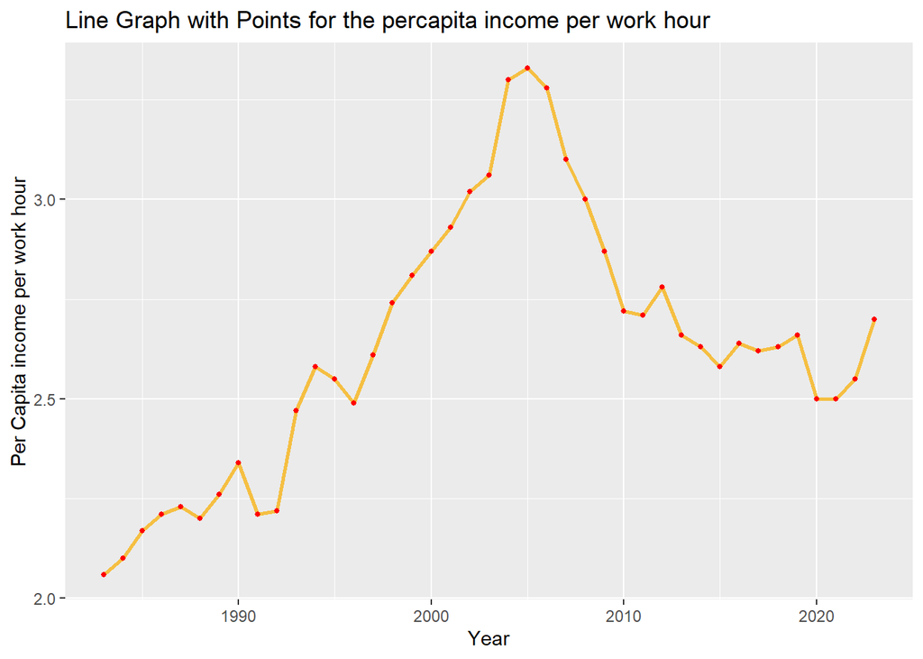

```r
#  line graph with points
ggplot(data, aes(x = Year, y = `IH`)) +
  geom_line(color = "#f5bf42",size = 1) +
  geom_point(shape = 16, size = 1, color = "red") +
  labs(x = "Year", y = "Per Capita income per work hour", title = "Line Graph with Points for the percapita income per work hour")
```

```r
  scale_x_continuous(breaks = seq(min(data$Year), max(data$Year), by = 2))
```

```
## <ScaleContinuousPosition>
##  Range:
##  Limits:    0 --    1
```

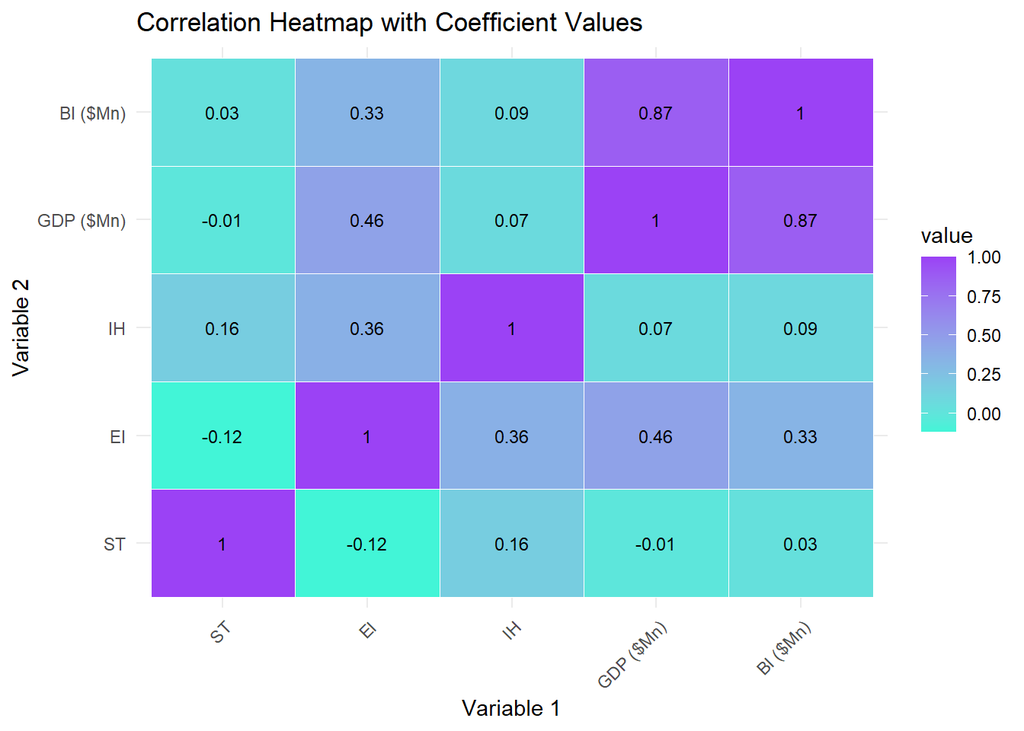

```r
library(ggplot2)
library(reshape2)

cor_matrix <- cor(data[, c("ST", "EI", "IH", "GDP ($Mn)","BI ($Mn)")])

cor_matrix_melted <- reshape2::melt(cor_matrix)

ggplot(data = cor_matrix_melted, aes(x = Var1, y = Var2)) +
  geom_tile(aes(fill = value), color = "white") +
  geom_text(aes(label = round(value, 2)), color = "black", size = 3) +
  scale_fill_gradient(low = "#42f5d7", high = "#9b42f5") +
  labs(title = "Correlation Heatmap with Coefficient Values",
       x = "Variable 1",
       y = "Variable 2") +
  theme_minimal() +
  theme(axis.text.x = element_text(angle = 45, hjust = 1))
```

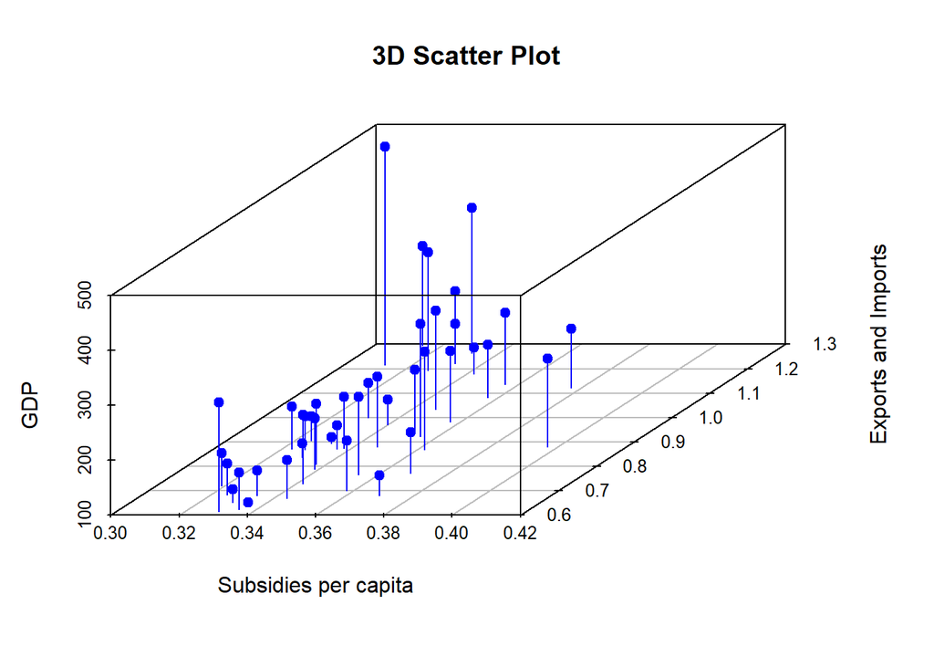

```r
library(scatterplot3d)
# Create a 3D scatter plot
scatterplot3d(data$ST, data$EI, data$`GDP ($Mn)`,
  color = "blue", pch = 19, type = "h", main = "3D Scatter Plot",
  xlab = "Subsidies per capita", ylab = "Exports and Imports", zlab = "GDP"
)
```

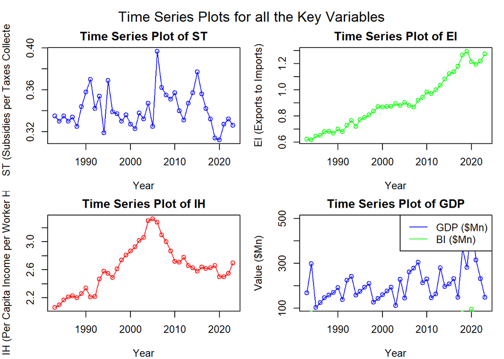

```r
# Define custom colors
colors <- c('blue', 'green', 'red', 'cyan')

# Setting up a multi-panel layout
par(mfrow = c(2, 2), mar = c(4, 4, 2, 1), oma = c(0, 0, 2, 0))

# Create time series plots for key variables with custom colors
plot(data$Year, data$ST, type = 'o', col = colors[1], xlab = 'Year', ylab = 'ST (Subsidies per Taxes Collected)', main = 'Time Series Plot of ST')
plot(data$Year, data$EI, type = 'o', col = colors[2], xlab = 'Year', ylab = 'EI (Exports to Imports)', main = 'Time Series Plot of EI')
plot(data$Year, data$IH, type = 'o', col = colors[3], xlab = 'Year', ylab = 'IH (Per Capita Income per Worker Hour)', main = 'Time Series Plot of IH')
plot(data$Year, data$`GDP ($Mn)`, type = 'o', col = colors[1], xlab = 'Year', ylab = 'Value ($Mn)', main = 'Time Series Plot of GDP')
lines(data$Year, data$`BI ($Mn)`, type = 'o', col = colors[2])
legend('topright', legend = c('GDP ($Mn)', 'BI ($Mn)'), col = colors[1:2], lty = 1)

# Add overall title
mtext('Time Series Plots for all the Key Variables', outer = TRUE, cex = 1.2)
```

```r
# Reset the plotting parameters
par(mfrow = c(1, 1), oma = c(0, 0, 0, 0))
```

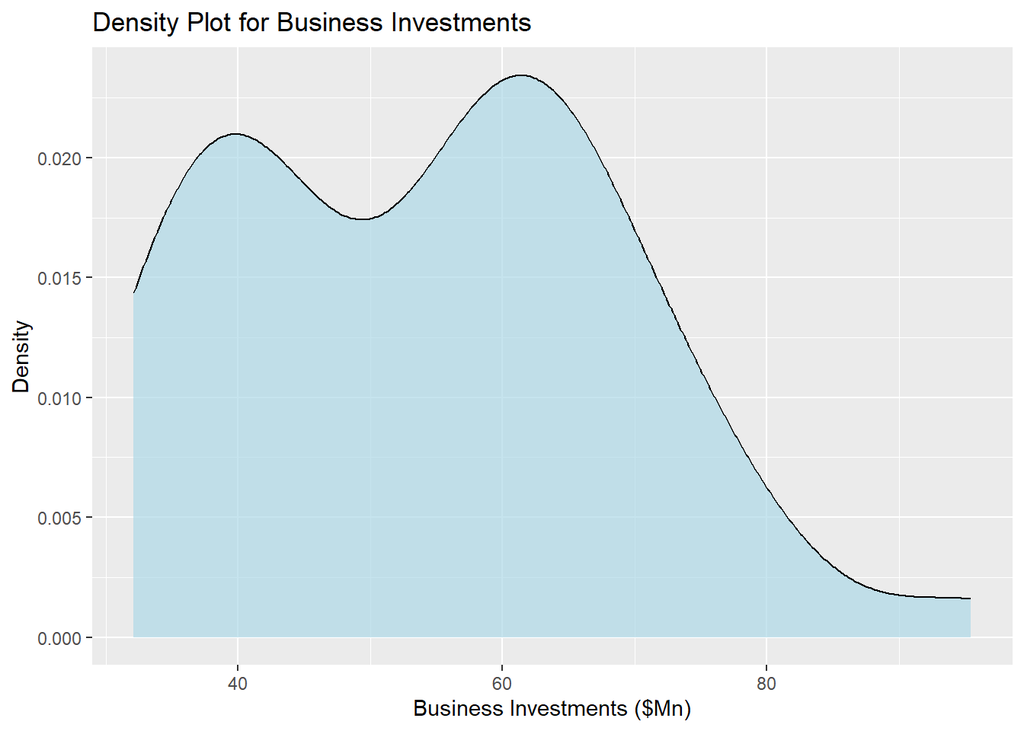

```r
# Load the ggplot2 package
library(ggplot2)

# Create a density plot for Business Investments
ggplot(data, aes(x = data$`BI ($Mn)`)) +
  geom_density(fill = "lightblue", alpha = 0.7) +
  labs(x = "Business Investments ($Mn)", y = "Density", title = "Density Plot for Business Investments")
```

The distribution shape seems not like bell shaped (symmetric).

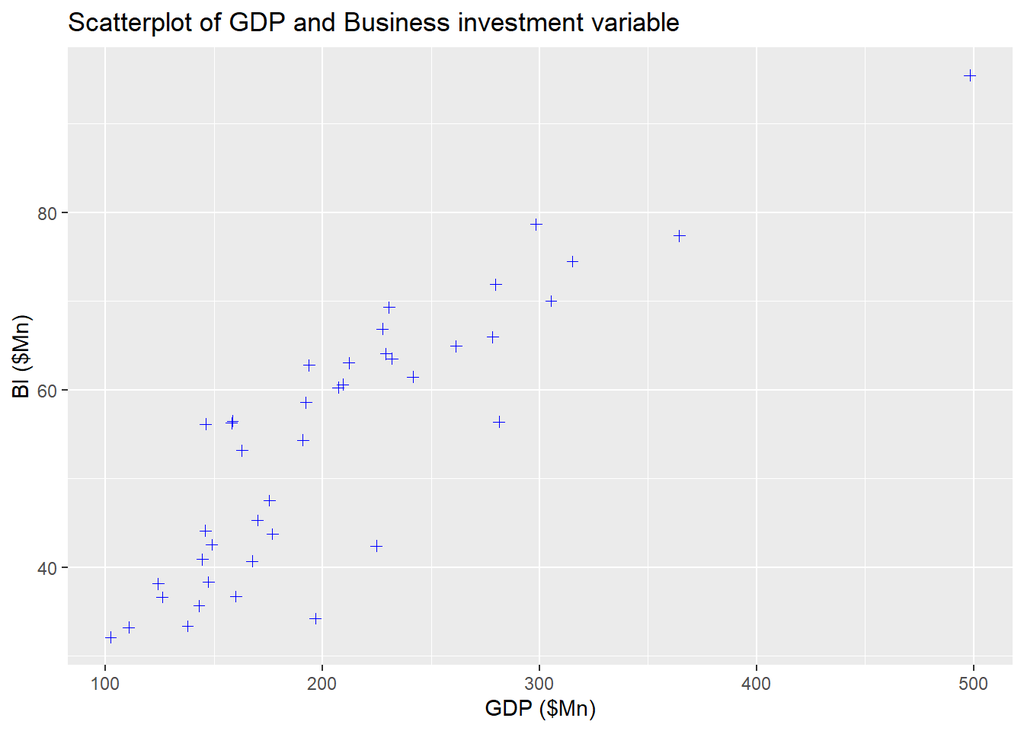

```r
ggplot(data, aes(x = `GDP ($Mn)`, y = `BI ($Mn)`)) +
  geom_point(color = "blue", shape = 3) +
  labs(title = "Scatterplot of GDP and Business investment variable")
```

#The scatterplot above shows the relationship/ correlation between GDP and Business investments. From the chart, a positive linear correlation is visible (When one variable increases, the other tend to increase as well). Inother word we can say that the both variable has a good positive relationship.

Step 4: Analysis and Interpretation. 1.Hypothesis testing.

hypothesis = is there any relationship between Export and index and the Bisiness Investment.

Null hypothesis(H0) = There is no relationship between Export and index and the Bisiness Investment. Alternate Hypothesis (H1) = There is a relationship between Export and index and the Bisiness Investment.

```r
lin_mod_EI_BI <- lm(EI~`BI ($Mn)`, data = data)
summary(lin_mod_EI_BI)
```

```
##
## Call:
## lm(formula = EI ~ `BI ($Mn)`, data = data)
##
## Residuals:
##      Min       1Q   Median       3Q      Max
## -0.39780 -0.13617 -0.00116  0.11127  0.42221
##
## Coefficients:
##             Estimate Std. Error t value Pr(>|t|)
## (Intercept) 0.662960   0.113248   5.854 8.26e-07 ***
## `BI ($Mn)`  0.004461   0.002010   2.219   0.0323 *
## ---
## Signif. codes:  0 '***' 0.001 '**' 0.01 '*' 0.05 '.' 0.1 ' ' 1
##
## Residual standard error: 0.1923 on 39 degrees of freedom
## Multiple R-squared:  0.1121, Adjusted R-squared:  0.08938
## F-statistic: 4.926 on 1 and 39 DF,  p-value: 0.03234
```